# Visualización de datos migratorios de Colombia

Semillero Computacional USTA, Hasbleidy Andrea Sastoque

2021-1

## Introducción

La base de datos utilizada para el presente trabajo de investigación es suministrada por el Departamento Administrativo Nacional de Estadística (DANE), del cual se tomaron los datos de los ultimos dos Censos realizados en Colombia en el año 2005 y 2018. Las variables trabajadas son Departamento de residencia hace 5 años, Departamento acual, Edad y Sexo.

#### Departamentos trabajados:

Cabe resaltar que Bogotá pertenece al departamento de Cundinamarca, sin embargo al ser la ciudad capital de Colombia el DANE suministra los datos de Bogotá y su respectivo departamento de manera separada.

```
##  [1] "Antioquia"                "Atlántico"
##  [3] "Bogotá"                   "Bolívar"
##  [5] "Boyacá"                   "Caldas"
##  [7] "Caquetá"                  "Cauca"
##  [9] "Cesar"                    "Córdoba"
## [11] "Cundinamarca"             "Chocó"
## [13] "Huila"                    "La Guajira"
## [15] "Magdalena"                "Meta"
## [17] "Nariño"                   "Norte De Santander"
## [19] "Quindío"                  "Risaralda"
## [21] "Santander"                "Sucre"
## [23] "Tolima"                   "Valle Del Cauca"
## [25] "Arauca"                   "Casanare"
## [27] "Putumayo"                 "San Andrés y Providencia"
## [29] "Amazonas"                 "Guainía"
## [31] "Guaviare"                 "Vaupés"
## [33] "Vichada"
```

### Analisis Censo 2018

### **Emigrantes**

#### 10 departamentos con un mayor flujo de emigrantes en terminos absolutos.

El porcentaje calculado es a partir de la poblacion total de cada departamento, es decir que de la poblacion total de Córdoba el 4.03% representa a la poblacion emigrante del departamento de los cuales el 50.19% son mujeres y el 49.81% son hombres.

```
##       Departamento Emigrantes Mujeres (%) Hombres (%) Porcentaje total
## 10          Bogotá     513930       51.28       48.72             7.42
## 9        Antioquia     118689       49.89       50.11             2.14
## 8  Valle Del Cauca      99934       50.28       49.72             2.82
## 7     Cundinamarca      97247       51.57       48.43             3.73
## 6        Santander      80670       50.90       49.10             4.31
## 5           Tolima      75756       50.38       49.62             6.33
## 4          Bolívar      74707       50.39       49.61             4.26
## 3           Boyacá      67444       51.07       48.93             6.13
## 2        Atlántico      61584       51.57       48.43             2.94
## 1          Córdoba      59017       50.19       49.81             4.03
```

#### 10 departamentos con un mayor porcentaje de emigrantes en relación a su población total.

```
##    Departamento Emigrantes Mujeres (%) Hombres (%) Porcentaje total
## 10     Guaviare       6724       45.69       54.31            10.01
## 9       Caquetá      32470       48.96       51.04             9.39
## 8        Bogotá     513930       51.28       48.72             7.42
## 7       Vichada       4636       46.46       53.54             7.37
## 6      Casanare      25526       49.46       50.54             7.11
## 5      Amazonas       3714       49.17       50.83             6.57
## 4        Arauca      13513       48.50       51.50             6.47
## 3          Meta      55411       49.48       50.52             6.39
## 2        Tolima      75756       50.38       49.62             6.33
## 1        Boyacá      67444       51.07       48.93             6.13
```

La siguiente grafica indica que del total de la poblacion emigrante en Colombia en el año 2018, el 27.31% pertenece a Bogotá.

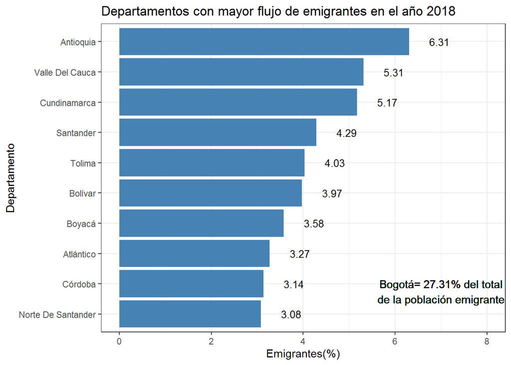

#### 10 departamentos con un menor flujo de emigrantes en terminos absolutos:

Cabe resaltar que en la tabla aparece el departamento del Guaviare, pero debido a que su poblacion es menor, el flujo de emigrantes es poco por tal motivo es más relevante el destacar estos datos a partir de los porcentajes totales en relación a su población.

```
##                Departamento Emigrantes Mujeres (%) Hombres (%) porcentaje
## 1                    Vaupés       1300       48.46       51.54       4.94
## 2                   Guainía       1499       46.30       53.70       4.56
## 3  San Andrés y Providencia       2605       44.61       55.39       5.59
## 4                  Amazonas       3714       49.17       50.83       6.57
## 5                   Vichada       4636       46.46       53.54       7.37
## 6                  Guaviare       6724       45.69       54.31      10.01
## 7                    Arauca      13513       48.50       51.50       6.47
## 8                  Putumayo      15960       49.47       50.53       6.02
## 9                     Chocó      22799       50.50       49.50       5.57
## 10                  Quindío      23599       51.22       48.78       4.81
```

#### 10 departamentos con menor porcentaje de emigrantes en relación a su población total.

```
##       Departamento Emigrantes Mujeres (%) Hombres (%) Porcentaje
## 1        Antioquia     118689       49.89       50.11       2.14
## 2  Valle Del Cauca      99934       50.28       49.72       2.82
## 3        Atlántico      61584       51.57       48.43       2.94
## 4           Nariño      37339       50.24       49.76       2.97
## 5            Cauca      39949       51.19       48.81       3.43
## 6       La Guajira      24006       51.12       48.88       3.46
## 7     Cundinamarca      97247       51.57       48.43       3.73
## 8          Córdoba      59017       50.19       49.81       4.03
## 9            Sucre      32174       50.81       49.19       4.03
## 10         Bolívar      74707       50.39       49.61       4.26
```

Nube de palabras de los principales departamentos de llegada para las personas de Antioquia, si se desea observar los datos de los otros departamentos, desde el codigo solo se cambia el dato de Antioquia por el departamento que se quiera observar.

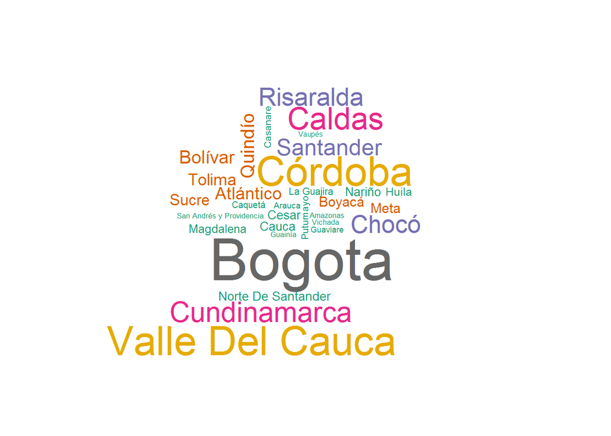

```r
#Para este codigo se utiliza la hoja: MatrizEm, si bien es similar a la matriz original, en este caso no tiene los datos de los no migrantes y las columnas muestran solo la informacion de los emigrantes

M <- read_excel("C:/Users/HASBLEIDY/Desktop/Semillero/Migracion/MIGRACION2018.xlsx", sheet = "MatrizEm") #Columnas= Informacion de los emigrantes

Mbog <- M[-11,] #se elimino la fila de cundinamarca, usar solo cuando se desee ver solo el caso de Bogota

wordcloud(words = M$DEPARTAMENTO, freq = M$Antioquia,
          random.order = T,colors = brewer.pal(8,"Dark2"),min.freq = 10)
```

```r
#### NOTA: Para bogota, se debe eliminar la fila de Cundinamarca para ver de una mejor manera los otros departamentos (Cundinamarca es el departamento que en su mayoria las personas de Bogota emigran):

#Codigo para Bogota:

#wc1 <- wordcloud(words = Mbog$DEPARTAMENTO, freq = Mbog$Bogota, random.order = T,colors = brewer.pal(8,"Dark2"))
```

### **Inmigrantes**

#### 10 departamentos con un mayor flujo de inmigrantes en terminos absolutos

```
##       Departamento Inmigrantes Mujeres (%) Hombres (%) Porcentaje total
## 10    Cundinamarca      368065       51.27       48.73            14.13
## 9           Bogotá      309715       52.55       47.45             4.47
## 8        Antioquia      169239       49.57       50.43             3.05
## 7  Valle Del Cauca      123596       51.47       48.53             3.48
## 6        Santander       78341       50.56       49.44             4.19
## 5             Meta       67170       49.27       50.73             7.75
## 4           Tolima       64501       49.41       50.59             5.39
## 3           Boyacá       58511       49.91       50.09             5.32
## 2        Risaralda       54851       50.85       49.15             6.82
## 1        Atlántico       54532       51.46       48.54             2.60
```

#### 10 departamentos con un mayor porcentaje de inmigrantes en relación a su población total.

```
##    Departamento Inmigrantes Mujeres (%) Hombres (%) Porcentaje total
## 10 Cundinamarca      368065       51.27       48.73            14.13
## 9      Guaviare        8224       47.84       52.16            12.25
## 8          Meta       67170       49.27       50.73             7.75
## 7       Quindío       37796       50.58       49.42             7.70
## 6      Casanare       26412       49.10       50.90             7.36
## 5      Putumayo       18797       48.74       51.26             7.09
## 4     Risaralda       54851       50.85       49.15             6.82
## 3        Arauca       12050       48.46       51.54             5.77
## 1        Caldas       51284       49.80       50.20             5.70
## 2       Caquetá       19714       48.76       51.24             5.70
```

La siguiente grafica indica que del total de la población inmigrante en Colombia, el 19.46% pertece a Cundinamarca.

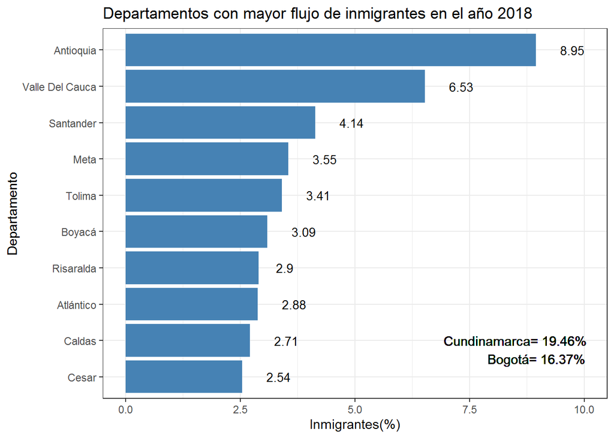

#### 10 departamentos con un menor flujo de inmigrantes en terminos absolutos

Cabe resaltar que Guaviare tambien sale, debido a que si se observan los datos del total de inmigrantes, la cantidad de los mismos en este departamento son menores en relación a otros departamentos del pais, por tal motivo tambien se colocan los datos en relación a la población total.

```
##                Departamento Inmigrantes Mujeres (%) Hombres (%) Porcentaje
## 1                    Vaupés         915       44.37       55.63       3.48
## 2  San Andrés y Providencia        1360       44.34       55.66       2.92
## 3                   Guainía        1861       45.84       54.16       5.66
## 4                  Amazonas        2213       44.92       55.08       3.92
## 5                   Vichada        3470       44.84       55.16       5.52
## 6                  Guaviare        8224       47.84       52.16      12.25
## 7                    Arauca       12050       48.46       51.54       5.77
## 8                     Chocó       12626       49.93       50.07       3.09
## 9                La Guajira       16526       50.79       49.21       2.38
## 10                 Putumayo       18797       48.74       51.26       7.09
```

#### 10 departamentos con menor porcentaje de inmigrantes en relacion a su poblacion total.

Como se observa para este caso, el departamento de Guaviare no sale en los resultados.

```
##                Departamento Inmigrantes Mujeres (%) Hombres (%) Porcentaje
## 1                    Nariño       25511       48.40       51.60       2.03
## 2                   Bolívar       39608       50.08       49.92       2.26
## 3                La Guajira       16526       50.79       49.21       2.38
## 4        Norte De Santander       30654       48.09       51.91       2.57
## 5                   Córdoba       37816       51.00       49.00       2.58
## 6                 Atlántico       54532       51.46       48.54       2.60
## 7  San Andrés y Providencia        1360       44.34       55.66       2.92
## 8                 Magdalena       34446       50.98       49.02       3.01
## 9                 Antioquia      169239       49.57       50.43       3.05
## 10                    Chocó       12626       49.93       50.07       3.09
```

Nube de palabras de los principales departamientos de las personas que inmigran a Antioquia.Si se desea observar los datos de los otros departamentos, desde el codigo solo se cambia el dato de Antioquia por el departamento que se quiera observar.

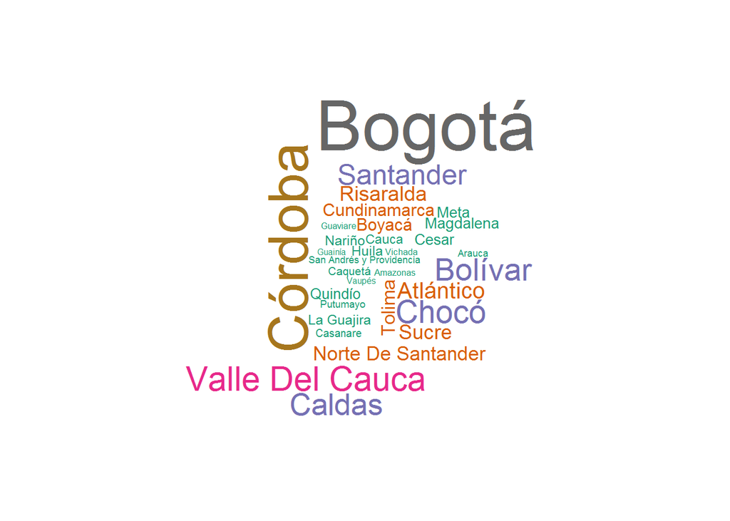

```r
MI <- read_excel("C:/Users/HASBLEIDY/Desktop/Semillero/Migracion/MIGRACION2018.xlsx", sheet = "MatrizInm") #Columnas= Informacion de los inmigrantes

wordcloud(words = MI$DEPARTAMENTO, freq = MI$Antioquia,
          random.order = T,colors = brewer.pal(8,"Dark2"))
```

```r
#NOTA: Para Bogotá el dato con mayor frecuencia es Cundinamarca
```

### Analisis Censo 2005

### **Emigrantes**

#### 10 departamentos con un mayor flujo de emigrantes en terminos absolutos.

```
##       Departamento Emigrantes Mujeres (%) Hombres (%) Porcentaje total
## 10          Bogotá     285283       48.39       51.61             4.54
## 9  Valle Del Cauca     110163       48.15       51.85             2.93
## 8        Antioquia     100724       48.38       51.62             2.00
## 7     Cundinamarca      93791       50.13       49.87             4.55
## 6           Tolima      93292       48.96       51.04             7.38
## 5        Santander      71515       49.10       50.90             4.00
## 4           Caldas      71441       50.05       49.95             8.09
## 3           Boyacá      69024       49.98       50.02             6.01
## 2          Bolívar      57572       50.66       49.34             3.48
## 1        Atlántico      57120       49.91       50.09             2.95
```

#### 10 departamentos con un mayor porcentaje de emigrantes en relación a su población total.

```
##    Departamento Emigrantes Mujeres (%) Hombres (%) Porcentaje total
## 10     Guaviare      10981       46.61       53.39            20.68
## 9       Caquetá      31391       48.97       51.03            10.32
## 8      Putumayo      19863       48.41       51.59            10.13
## 7        Arauca      14499       49.13       50.87            10.03
## 6       Vichada       3126       45.20       54.80             8.82
## 5        Caldas      71441       50.05       49.95             8.09
## 4        Tolima      93292       48.96       51.04             7.38
## 3        Vaupés       1075       50.88       49.12             7.05
## 2       Guainía       1139       46.09       53.91             6.92
## 1         Chocó      20357       52.92       47.08             6.53
```

La siguiente grafica indica que del total de la poblacion emigrante en Colombia en el año 2005, el 18.01% pertenece a Bogotá.

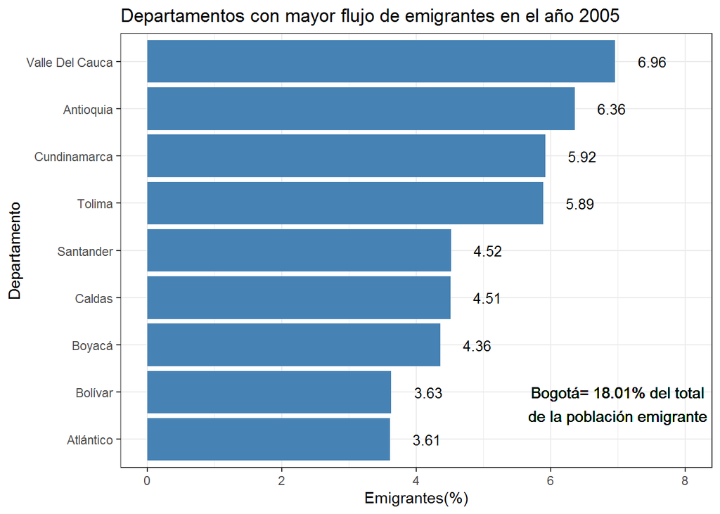

#### 10 departamentos con un menor flujo de emigrantes en terminos absolutos

```
##    Departamento Emigrantes Mujeres (%) Hombres (%) Porcentaje
## 1        Vaupés       1075       50.88       49.12       7.05
## 2       Guainía       1139       46.09       53.91       6.92
## 3      Amazonas       2328       49.87       50.13       5.86
## 4       Vichada       3126       45.20       54.80       8.82
## 5    San Andrés       3233       48.44       51.56       5.72
## 6      Guaviare      10981       46.61       53.39      20.68
## 7        Arauca      14499       49.13       50.87      10.03
## 8      Casanare      16569       47.12       52.88       6.30
## 9    La Guajira      18857       51.38       48.62       3.56
## 10     Putumayo      19863       48.41       51.59      10.13
```

##### 10 departamentos con menor porcentaje de emigrantes en relación a su población total.

```
##          Departamento Emigrantes Mujeres (%) Hombres (%) Porcentaje
## 1           Antioquia     100724       48.38       51.62       2.00
## 2              Nariño      30211       50.55       49.45       2.30
## 3     Valle Del Cauca     110163       48.15       51.85       2.93
## 4           Atlántico      57120       49.91       50.09       2.95
## 5             Córdoba      45288       50.70       49.30       3.41
## 6             Bolívar      57572       50.66       49.34       3.48
## 7          La Guajira      18857       51.38       48.62       3.56
## 8  Norte de Santander      40600       49.30       50.70       3.65
## 9               Cauca      38535       52.78       47.22       3.66
## 10          Santander      71515       49.10       50.90       4.00
```

Nube de palabras de los principales departamentos de llegada para las personas de Antioquia, si se desea observar los datos de los otros departamentos, desde el codigo solo se cambia el dato de Antioquia por el departamento que se quiera observar.

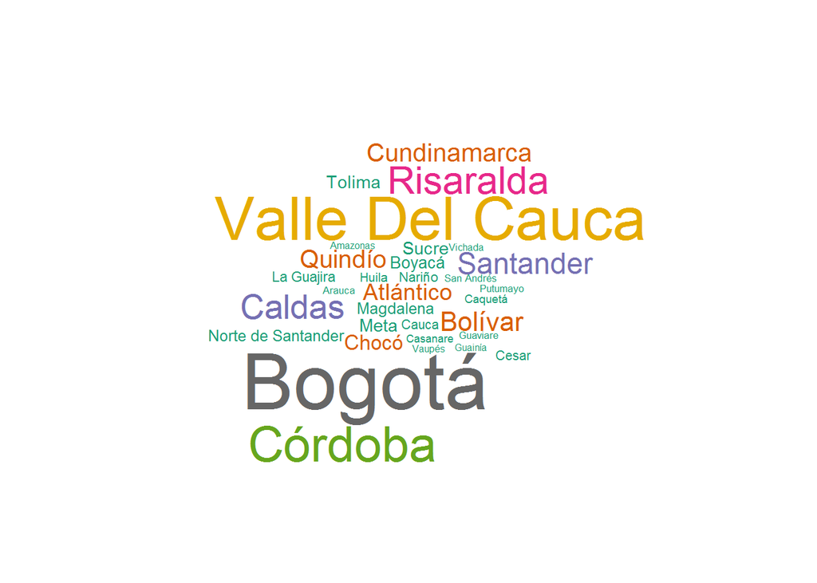

```r
M2005 <- read_excel("C:/Users/HASBLEIDY/Desktop/Semillero/Migracion/MIGRACION2005.xlsx", sheet = "MatrizEm") #Columnas= Informacion de los emigrantes

wordcloud(words = M2005$Departamento, freq = M2005$Antioquia,
          random.order = T,colors = brewer.pal(8,"Dark2"))
```

### **Inmigrantes**

#### 10 departamentos con un mayor flujo de inmigrantes en terminos absolutos

```
##       Departamento Inmigrantes Mujeres (%) Hombres (%) Porcentaje total
## 10          Bogotá      344211       52.32       47.68             5.48
## 9     Cundinamarca      195087       48.09       51.91             9.45
## 8  Valle Del Cauca      131342       51.00       49.00             3.49
## 7        Antioquia      118970       48.34       51.66             2.36
## 6        Santander       76033       48.71       51.29             4.25
## 5             Meta       67830       46.71       53.29            10.21
## 4        Risaralda       66091       50.26       49.74             8.06
## 3        Atlántico       54346       53.56       46.44             2.81
## 2           Tolima       51865       47.45       52.55             4.10
## 1           Boyacá       46060       43.84       56.16             4.01
```

##### 10 departamentos con un mayor porcentaje de inmigrantes en relación a su población total.

```
##    Departamento Inmigrantes Mujeres (%) Hombres (%) Porcentaje total
## 10         Meta       67830       46.71       53.29            10.21
## 9  Cundinamarca      195087       48.09       51.91             9.45
## 8       Quindío       41931       49.24       50.76             8.27
## 7     Risaralda       66091       50.26       49.74             8.06
## 6        Vaupés        1199       46.77       53.23             7.86
## 5       Vichada        2710       39.65       60.35             7.65
## 4      Casanare       19994       48.28       51.72             7.60
## 3      Guaviare        3110       49.39       50.61             5.86
## 2        Arauca        8166       32.00       68.00             5.65
## 1        Bogotá      344211       52.32       47.68             5.48
```

La siguiente grafica indica que del total de la poblacion inmigrante en Colombia, el 21.73% pertece a Bogotá.

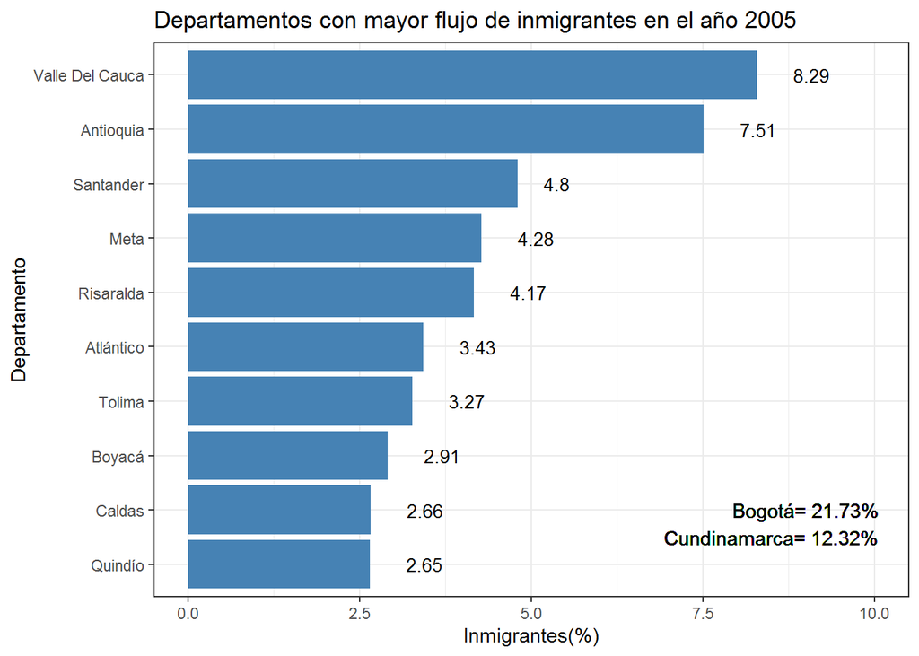

#### 10 departamentos con un menor flujo de inmigrantes en terminos absolutos

```
##    Departamento Inmigrantes Mujeres (%) Hombres (%) Porcentaje
## 1       Guainía         429       47.43       52.57       2.61
## 2      Amazonas        1049       36.83       63.17       2.64
## 3        Vaupés        1199       46.77       53.23       7.86
## 4    San Andrés        1690       46.06       53.94       2.99
## 5       Vichada        2710       39.65       60.35       7.65
## 6      Guaviare        3110       49.39       50.61       5.86
## 7      Putumayo        4885       48.02       51.98       2.49
## 8         Chocó        5024       47.55       52.45       1.61
## 9        Arauca        8166       32.00       68.00       5.65
## 10      Caquetá       13277       45.21       54.79       4.36
```

#### 10 departamentos con menor porcentaje de inmigrantes en relación a su población total.

```
##    Departamento Inmigrantes Mujeres (%) Hombres (%) Porcentaje
## 1         Chocó        5024       47.55       52.45       1.61
## 2        Nariño       23534       47.37       52.63       1.79
## 3       Córdoba       27911       50.46       49.54       2.10
## 4         Sucre       16311       48.06       51.94       2.32
## 5       Bolívar       38760       50.45       49.55       2.34
## 6     Antioquia      118970       48.34       51.66       2.36
## 7      Putumayo        4885       48.02       51.98       2.49
## 8       Guainía         429       47.43       52.57       2.61
## 9      Amazonas        1049       36.83       63.17       2.64
## 10    Atlántico       54346       53.56       46.44       2.81
```

Nube de palabras de los principales departamientos de las personas que inmigran a Antioquia.Si se desea observar los datos de los otros departamentos, desde el codigo solo se cambia el dato de Antioquia por el departamento que se quiera observar.

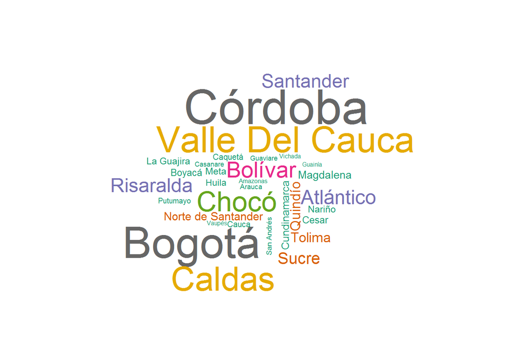

```r
MI2005 <- read_excel("C:/Users/HASBLEIDY/Desktop/Semillero/Migracion/MIGRACION2005.xlsx", sheet = "MatrizInm") #Columnas= Informacion de los inmigrantes

wordcloud(words = MI2005$Departamento, freq = MI2005$Antioquia,
          random.order = T,colors = brewer.pal(8,"Dark2"))
```